# Linear Model

Felix Bigler

11/12/2021

# 1 Linear Regression Model

## 1.1 Data Preperation for the Linear Model

### 1.1.1 Set Categorical Variables as Factors

```r
df$season <- factor(df$season, levels = c("1", "2", "3", "4"), ordered = FALSE)
df$yr <- as.factor(df$yr)
df$mnth <- as.factor(df$mnth)
df$hr <- as.factor(df$hr)
df$holiday <- as.factor(df$holiday)
df$weekday <- as.factor(df$weekday)
df$workingday <- as.factor(df$workingday)
df$weathersit <- as.factor(df$weathersit)
```

### 1.1.2 Re-Transform the Continious Weather Variables

As described in the data exploration chapter, the continuous weather variables have been normalized in the existing dataset. In order to make interpretation of the coefficients more straight forward in the linear model the variables will be re-transformed to the actual values as follows. For more advanced models the normalized variables may be the better choice to fit a model.

```r
df$temperature <- (df$temp * (39 + 8)) - 8
df$atemperature <- (df$atemp * (39 + 8)) - 8
df$humidity <- (df$hum * 100)
df$wind <- (df$windspeed * 67)
```

### 1.1.3 Split data into train and test dataset

In the following the dataset will be split into a train and a test dataset. The partition will be used to evaluate the accuracy of the model when used on the test data.

```r
set.seed(123)
indices <- createDataPartition(df$cnt, p=.8, list = F)
train <- df %>% slice(indices)
test <- df %>% slice(-indices)
```

## 1.2 Multiple Linear Regression Model with Continious Weather Predictors

First of all we want to include only the continuous variables in the model.

```r
lm.fit.0.train <- lm(log(cnt) ~ temperature + atemperature + humidity + wind,data=train)
summary(lm.fit.0.train)
```

```
##
## Call:
## lm(formula = log(cnt) ~ temperature + atemperature + humidity +
##     wind, data = train)
##
## Residuals:
##     Min      1Q  Median      3Q     Max
## -5.5444 -0.6400  0.2519  0.8710  3.2934
##
## Coefficients:
##                Estimate Std. Error t value Pr(>|t|)
## (Intercept)   4.9326457  0.0531309  92.839  < 2e-16 ***
## temperature   0.0029451  0.0080521   0.366    0.715
## atemperature  0.0640689  0.0090373   7.089 1.41e-12 ***
## humidity     -0.0234304  0.0005942 -39.429  < 2e-16 ***
## wind          0.0083912  0.0014307   5.865 4.59e-09 ***
## ---
## Signif. codes:  0 '***' 0.001 '**' 0.01 '*' 0.05 '.' 0.1 ' ' 1
##
## Residual standard error: 1.29 on 13899 degrees of freedom
## Multiple R-squared:  0.2465, Adjusted R-squared:  0.2463
## F-statistic:  1137 on 4 and 13899 DF,  p-value: < 2.2e-16
```

### 1.2.1 Simplification of Model lm.fit.0.train

There is evidence that the predictor temperature has no significant influence since the p-value is large with 0.7. However the feels like temperature (atemperature) is a result of the combination of the temperature, the humidity and the wind at a given time. Moreover, the prediction of future bike rental will depend from the weather forecast. In the forecast the feels like temperature is not always available. Therefore we try to fit the model without atemperature to simplify it and make it more practical for future usage.

```r
lm.fit.1.train <- lm(log(cnt) ~ temperature + humidity + wind,data=train)
summary(lm.fit.1.train)
```

```
##
## Call:
## lm(formula = log(cnt) ~ temperature + humidity + wind, data = train)
##
## Residuals:
##     Min      1Q  Median      3Q     Max
## -5.5827 -0.6534  0.2505  0.8791  3.3242
##
## Coefficients:
##               Estimate Std. Error t value Pr(>|t|)
## (Intercept)  5.0052296  0.0522274  95.835  < 2e-16 ***
## temperature  0.0593705  0.0012224  48.570  < 2e-16 ***
## humidity    -0.0232619  0.0005948 -39.108  < 2e-16 ***
## wind         0.0060989  0.0013961   4.368 1.26e-05 ***
## ---
## Signif. codes:  0 '***' 0.001 '**' 0.01 '*' 0.05 '.' 0.1 ' ' 1
##
## Residual standard error: 1.292 on 13900 degrees of freedom
## Multiple R-squared:  0.2438, Adjusted R-squared:  0.2436
## F-statistic:  1494 on 3 and 13900 DF,  p-value: < 2.2e-16
```

Interpretation of Regression Coefficients:

- As we can see from the output above the predictor temperature and wind have both a positive influence upon the number of bike rentals. A increase of one unit (temperature) leads to a increase of 5.9 % rentals and 0.6 % when the wind is increased by one unit. The humidity on the other hand has a negative influence. If the humidity is increased by one unit the number of rentals decreases by 2.3 %.

### 1.2.2 Accessing the model accuracy

We evaluate the accuracy of both models by testing them with the test data partition. The R-squared will serve as an indication of the accuracy as well as the RSME values.

#### 1.2.2.1 Compare R-squared Values

```r
# Fit a linear model without the predictor atempereature and accessing both prediction performances with the test data and comparison of the R-squared value.

lm.fit.0.test = lm(formula(lm.fit.0.train),data=test)
lm.fit.1.test = lm(formula(lm.fit.1.train),data=test)

R2_0 <- summary(lm.fit.0.test)$r.squared
R2_1 <- summary(lm.fit.1.test)$r.squared

print(paste("R-squared of lm.fit.0:",round(R2_0,3)))
```

```
## [1] "R-squared of lm.fit.0: 0.258"
```

```r
print(paste("R-squared of lm.fit.1:",round(R2_1,3)))
```

```
## [1] "R-squared of lm.fit.1: 0.254"
```

- Both R-squared values are almost identical when applying the model on the test data. Therefore, the predictor atemperature shall be neglected for the linear model in the further model building.

#### 1.2.2.2 Compare RMSE Values

```r
control <- test$cnt
control_log <- log(control)
predict_0 <- predict(lm.fit.0.test)
predict_1 <- predict(lm.fit.1.test)

# take inverse of natural log to obtain RMSE with actual unit (number of bike rentals)
RMSE_0 <- sqrt(mean((exp(control_log) - exp(predict_0))^2))
RMSE_1 <- sqrt(mean((exp(control_log) - exp(predict_1))^2))

# calculate percentage error
percent_error_0 <- (RMSE_0/mean(control))*100
percent_error_1 <- (RMSE_1/mean(control))*100

print(paste("RMSE of lm.fit.0:",round(RMSE_0,1)))
```

```
## [1] "RMSE of lm.fit.0: 171.7"
```

```r
print(paste("Percentage error of lm.fit.1:",round(percent_error_0,1),"%"))
```

```
## [1] "Percentage error of lm.fit.1: 91 %"
```

```r
print(paste("RMSE of lm.fit.0:",round(RMSE_1,1)))
```

```
## [1] "RMSE of lm.fit.0: 173.5"
```

```r
print(paste("Percentage error of lm.fit.1:",round(percent_error_1,1),"%"))
```

```
## [1] "Percentage error of lm.fit.1: 92 %"
```

- The RMSE values for both models are roughly 170 units as we can see from the output above. This corresponds to a percentage error of around 90 % of the predicted values if it is compared with the mean of all bike rentals.

## 1.3 Multiple Linear Regression Model with Continious and Categorical Variables

```r
# Update the previous model lm.fit.1.train, including all the categorical variables.
lm.fit.2.train <- update(lm.fit.1.train,. ~ . + weathersit + hr + season + mnth + workingday + weekday + holiday + yr ,data=train)
formula(lm.fit.2.train)
```

```
## log(cnt) ~ temperature + humidity + wind + weathersit + hr +
##     season + mnth + workingday + weekday + holiday + yr
```

### 1.3.1 Simplification of Model lm.fit.2.train

In the next step we try fo find again a more simple and more practical model without reducing the predicting accuracy of the model significantly. With the drop1 function we test influence of the categorical variables with a F test as follows.

```r
drop1(lm.fit.2.train, test = "F")
```

```
## Single term deletions
##
## Model:
## log(cnt) ~ temperature + humidity + wind + weathersit + hr +
##     season + mnth + workingday + weekday + holiday + yr
##             Df Sum of Sq     RSS      AIC  F value    Pr(>F)
## <none>                    5422.5 -12988.4
## temperature  1     199.6  5622.0 -12487.9  509.768 < 2.2e-16 ***
## humidity     1      16.4  5438.9 -12948.3   42.000 9.435e-11 ***
## wind         1      12.0  5434.4 -12959.7   30.564 3.288e-08 ***
## weathersit   3     275.1  5697.6 -12306.3  234.242 < 2.2e-16 ***
## hr          23   15615.1 21037.6   5816.1 1734.333 < 2.2e-16 ***
## season       3     137.5  5560.0 -12646.1  117.104 < 2.2e-16 ***
## mnth        11      46.6  5469.0 -12891.5   10.815 < 2.2e-16 ***
## workingday   0       0.0  5422.5 -12988.4
## weekday      5      48.4  5470.9 -12874.8   24.726 < 2.2e-16 ***
## holiday      0       0.0  5422.5 -12988.4
## yr           1     746.9  6169.4 -11196.1 1908.057 < 2.2e-16 ***
## ---
## Signif. codes:  0 '***' 0.001 '**' 0.01 '*' 0.05 '.' 0.1 ' ' 1
```

There is evidence that the variables workingday an holiday have no significant influence according the results of the F-test. We therefore neglect this variables in the model lm.fit.3.train. The graphical analysis in the last chapter supports this step, showing that there is no influence of these variables.

```r
lm.fit.3.train <- update(lm.fit.1.train,. ~ . + weathersit + hr + season + mnth + weekday + yr ,data=train)
formula(lm.fit.3.train)
```

```
## log(cnt) ~ temperature + humidity + wind + weathersit + hr +
##     season + mnth + weekday + yr
```

### 1.3.2 Accessing the model accuracy

#### 1.3.2.1 Compare R-Squared Values

Again we compare the R-squared values of the 3 models.

```r
lm.fit.2.test = lm(formula(lm.fit.2.train),data=test)
lm.fit.3.test = lm(formula(lm.fit.3.train),data=test)

R2_2 <- summary(lm.fit.2.test)$r.squared
R2_3 <- summary(lm.fit.3.test)$r.squared

print(paste("R-squared of lm.fit.2:",round(R2_2,3)))
```

```
## [1] "R-squared of lm.fit.2: 0.828"
```

```r
print(paste("R-squared of lm.fit.3:",round(R2_3,3)))
```

```
## [1] "R-squared of lm.fit.3: 0.828"
```

- Form the previous model the the most simplified we can see only a marginal drop of the R-squared values. Therefore, it can be stated that the simplified model can be used without losing considerable information.

#### 1.3.2.2 Compare RMSE Values

```r
predict_2 <- predict(lm.fit.2.test)
predict_3 <- predict(lm.fit.3.test)

# take inverse of natural log to calculate RMSE with actual unit (number of bike rentals)
RMSE_2 <- sqrt(mean((exp(control_log) - exp(predict_2))^2))
RMSE_3 <- sqrt(mean((exp(control_log) - exp(predict_3))^2))

# Calculate percentage error (deviation to the mean of number of bike rentals)
percent_error_2 <- (RMSE_2/mean(control))*100
percent_error_3 <-(RMSE_3/mean(control))*100

print(paste("RMSE of lm.fit.2:",round(RMSE_2,1)))
```

```
## [1] "RMSE of lm.fit.2: 96.9"
```

```r
print(paste("Percentage error of lm.fit.2:",round(percent_error_2,1),"%"))
```

```
## [1] "Percentage error of lm.fit.2: 51.4 %"
```

```r
print(paste("RMSE of lm.fit.3:",round(RMSE_3,1)))
```

```
## [1] "RMSE of lm.fit.3: 97.4"
```

```r
print(paste("Percentage error of lm.fit.3:",round(percent_error_3,1),"%"))
```

```
## [1] "Percentage error of lm.fit.3: 51.7 %"
```

```r
summary(lm.fit.3.test)
```

```
##
## Call:
## lm(formula = formula(lm.fit.3.train), data = test)
##
## Residuals:
##      Min       1Q   Median       3Q      Max
## -3.08270 -0.30012  0.03358  0.38687  2.45689
##
## Coefficients:
##               Estimate Std. Error t value Pr(>|t|)
## (Intercept)  2.9158137  0.0870855  33.482  < 2e-16 ***
## temperature  0.0305188  0.0027727  11.007  < 2e-16 ***
## humidity    -0.0032520  0.0007683  -4.233 2.37e-05 ***
## wind        -0.0030975  0.0014167  -2.186 0.028852 *
## weathersit2  0.0076810  0.0264884   0.290 0.771853
## weathersit3 -0.6381223  0.0453287 -14.078  < 2e-16 ***
## hr1         -0.5711212  0.0760137  -7.513 7.31e-14 ***
## hr2         -1.1189292  0.0747507 -14.969  < 2e-16 ***
## hr3         -1.8115857  0.0770261 -23.519  < 2e-16 ***
## hr4         -2.1754243  0.0753524 -28.870  < 2e-16 ***
## hr5         -0.9880170  0.0740504 -13.343  < 2e-16 ***
## hr6          0.2699303  0.0733150   3.682 0.000235 ***
## hr7          1.1836421  0.0738777  16.022  < 2e-16 ***
## hr8          1.8113397  0.0745190  24.307  < 2e-16 ***
## hr9          1.5328528  0.0744233  20.596  < 2e-16 ***
## hr10         1.2074100  0.0772795  15.624  < 2e-16 ***
## hr11         1.3185236  0.0735631  17.924  < 2e-16 ***
## hr12         1.4677899  0.0777346  18.882  < 2e-16 ***
## hr13         1.5111936  0.0757884  19.940  < 2e-16 ***
## hr14         1.3687965  0.0787133  17.390  < 2e-16 ***
## hr15         1.3703310  0.0779888  17.571  < 2e-16 ***
## hr16         1.6749705  0.0772950  21.670  < 2e-16 ***
## hr17         2.0597478  0.0763519  26.977  < 2e-16 ***
## hr18         1.9987986  0.0763101  26.193  < 2e-16 ***
## hr19         1.7304255  0.0755409  22.907  < 2e-16 ***
## hr20         1.4462195  0.0745160  19.408  < 2e-16 ***
## hr21         1.1974803  0.0749683  15.973  < 2e-16 ***
## hr22         0.9688490  0.0767917  12.617  < 2e-16 ***
## hr23         0.5323629  0.0760673   6.999 3.10e-12 ***
## season2      0.3512380  0.0652387   5.384 7.78e-08 ***
```

[output cut: 11 more lines]

```
## mnth11      -0.0944324  0.0856004  -1.103 0.270028
## mnth12      -0.0512931  0.0685889  -0.748 0.454612
## weekday1    -0.0307332  0.0391408  -0.785 0.432393
## weekday2    -0.0725483  0.0403478  -1.798 0.072254 .
## weekday3    -0.0026584  0.0399542  -0.067 0.946956
## weekday4     0.0108687  0.0399415   0.272 0.785549
## weekday5     0.1119988  0.0390190   2.870 0.004125 **
## weekday6     0.0745011  0.0387918   1.921 0.054873 .
## yr1          0.4902112  0.0215924  22.703  < 2e-16 ***
## ---
## Signif. codes:  0 '***' 0.001 '**' 0.01 '*' 0.05 '.' 0.1 ' ' 1
##
## Residual standard error: 0.6225 on 3425 degrees of freedom
## Multiple R-squared:  0.8278, Adjusted R-squared:  0.8254
## F-statistic: 336.1 on 49 and 3425 DF,  p-value: < 2.2e-16
```

## 1.4 Summary

### 1.4.1 Is there a relationship betweeen the independent variables and the response variable?

As stated above there is evidence, that the weather as well as the timely and seasonal variables has influence of the number of bike rentals according to the P-values for the continuous variables as well as the outcome of the F-test for the categorical variables.

### 1.4.3 How large is the effect of each predctor on cnt?

To answer this question we will plot the confidence interval of all the predictors.

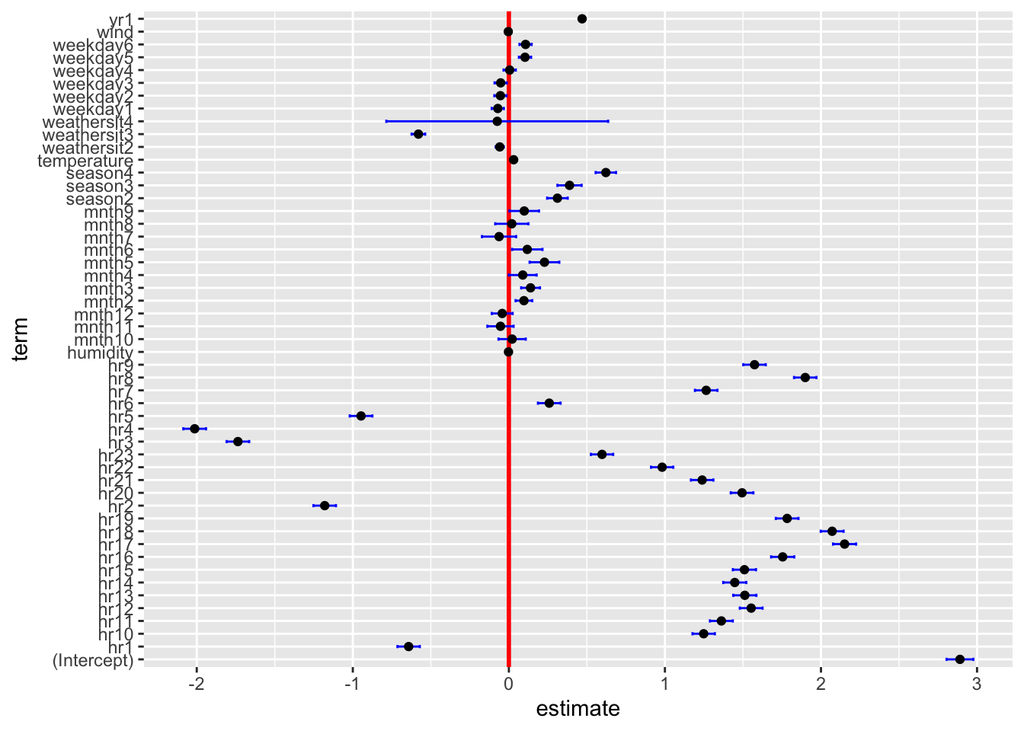

```r
ggcoef(lm.fit.3.train,vline_color = "red", vline_linetype =  "solid", errorbar_color = "blue", errorbar_height = .25)
```

```r
lm.fit.4.train <- update(lm.fit.1.train,. ~ . + weathersit + hr+ season + weekday ,data=df)
lm.fit.4.test = lm(formula(lm.fit.4.train),data=test)

summary(lm.fit.3.test)$r.squared
```

```
## [1] 0.8278342
```

```r
summary(lm.fit.4.test)$r.squared
```

```
## [1] 0.7996572
```

### 1.4.4 Are there Potential Problems of Fitting this data with a Linear Regression Model

With the plot function, we try to examine our model in more detail by means of residual analysis.To to that we build a model with the entire dataset.

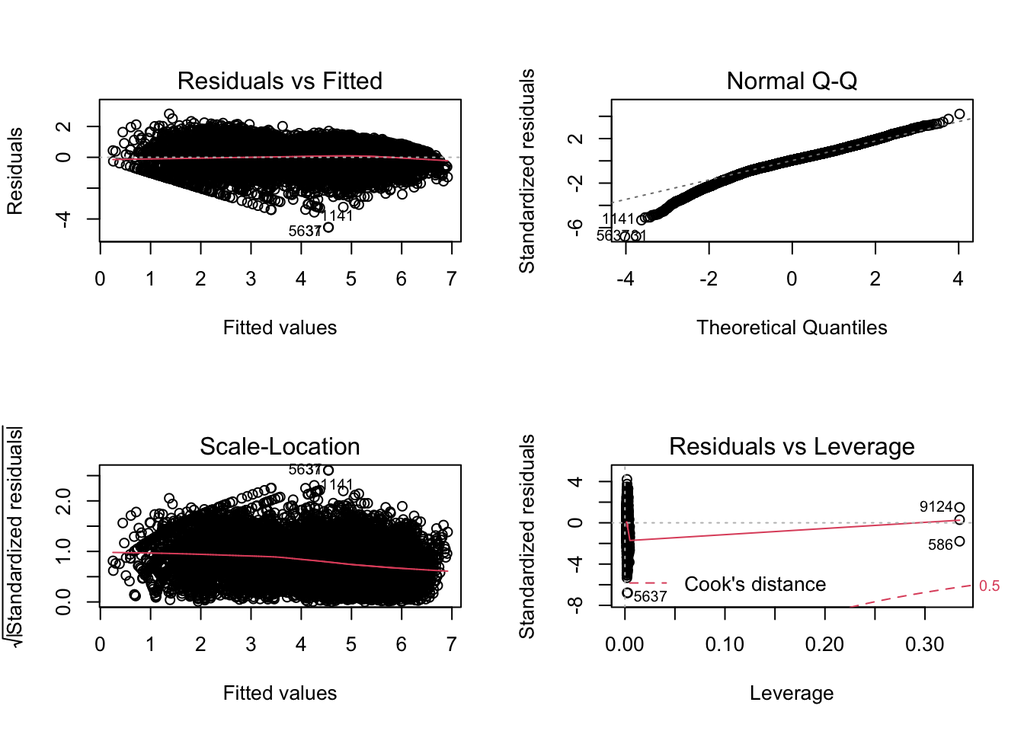

```r
lm.fit.0.full = lm(formula(lm.fit.4.train),data=df)
par(mfrow=c(2,2))
plot(lm.fit.0.full)
```

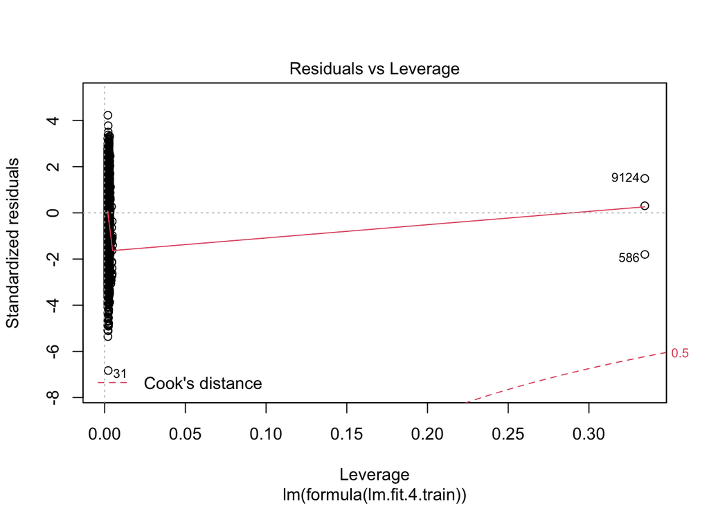

```r
df2 <- df[!(df$dteday=="2011-08-27" | df$dteday=="2011-08-28"),]
lm.fit.1.full = lm(formula(lm.fit.4.train),data=df2)
plot(lm.fit.1.full, which = 5)
```

```r
summary(lm.fit.0.full)$r.squared
```

```
## [1] 0.7972013
```

```r
summary(lm.fit.1.full)$r.squared
```

```
## [1] 0.7984692
```

- As we can see, all observations are lying now within the cook distance and the R-value also increases marginally when taking out the faulty date entries in a updated dataset.

In the next chapter we will use more advanced linear models to find a better fit for the data.

# 2 General Additive Model (GAM)

In this chapter we would like to use the GAM model to address for possible non-linear relationships and improve the basic linear mode lm.fit.3.

## 2.1 Check if model with non-linear function ist better

```r
gam_0_train <- gam(log(cnt) ~ temperature + humidity + wind,data=train)
gam_1_train <- gam(log(cnt) ~ s(temperature) + humidity + wind,data=train)
gam_2_train <- gam(log(cnt) ~ temperature + s(humidity) + wind,data=train)
gam_3_train <- gam(log(cnt) ~ temperature + humidity + s(wind),data=train)

anova(gam_0_train,gam_1_train,gam_2_train,gam_3_train,test="F")
```

```
## Analysis of Deviance Table
##
## Model 1: log(cnt) ~ temperature + humidity + wind
## Model 2: log(cnt) ~ s(temperature) + humidity + wind
## Model 3: log(cnt) ~ temperature + s(humidity) + wind
## Model 4: log(cnt) ~ temperature + humidity + s(wind)
##   Resid. Df Resid. Dev       Df Deviance        F    Pr(>F)
## 1     13900      23196
## 2     13892      22737  7.96329   458.54   35.183 < 2.2e-16 ***
## 3     13892      22978 -0.10501  -240.84 1401.296 < 2.2e-16 ***
## 4     13895      23161 -3.15690  -182.71   35.363 < 2.2e-16 ***
## ---
## Signif. codes:  0 '***' 0.001 '**' 0.01 '*' 0.05 '.' 0.1 ' ' 1
```

- There is strong evidence that for all models applying the smoothing splines for the 3 continuous weather predictors is needed to improve the model. Consequently we will use the model applying the smoothing splines on all 3 weather predictor.

### 2.1.1 Compare RMSE Values

```r
gam_4_train <- gam(log(cnt) ~ s(temperature) + s(humidity) + s(wind),data=train)

gam_0_test <- gam(formula(gam_0_train),data=test)
gam_1_test <- gam(formula(gam_1_train),data=test)
gam_2_test <- gam(formula(gam_2_train),data=test)
gam_3_test <- gam(formula(gam_3_train),data=test)
gam_4_test <- gam(formula(gam_4_train),data=test)

predict_gam_0 <- predict(gam_0_test)
predict_gam_1 <- predict(gam_1_test)
predict_gam_2 <- predict(gam_2_test)
predict_gam_3 <- predict(gam_3_test)
predict_gam_4 <- predict(gam_4_test)

# take inverse of natural log to calculate RMSE with actual unit (number of bike rentals)
RMSE_gam_0 <- sqrt(mean((exp(control_log) - exp(predict_gam_0))^2))
RMSE_gam_1 <- sqrt(mean((exp(control_log) - exp(predict_gam_1))^2))
RMSE_gam_2 <- sqrt(mean((exp(control_log) - exp(predict_gam_2))^2))
RMSE_gam_3 <- sqrt(mean((exp(control_log) - exp(predict_gam_3))^2))
RMSE_gam_4 <- sqrt(mean((exp(control_log) - exp(predict_gam_4))^2))

print(paste("RMSE of gam_01(simple linear model):",round(RMSE_gam_0,1)))
```

```
## [1] "RMSE of gam_01(simple linear model): 173.5"
```

```r
print(paste("RMSE of gam_02(s(temperature)):",round(RMSE_gam_1,1)))
```

```
## [1] "RMSE of gam_02(s(temperature)): 166.9"
```

```r
print(paste("RMSE of gam_02(s(humidity)):",round(RMSE_gam_2,1)))
```

```
## [1] "RMSE of gam_02(s(humidity)): 171.6"
```

```r
print(paste("RMSE of gam_02(s(wind)):",round(RMSE_gam_3,1)))
```

```
## [1] "RMSE of gam_02(s(wind)): 172.9"
```

```r
print(paste("RMSE of gam_02(s(on all variables)):",round(RMSE_gam_4,1)))
```

```
## [1] "RMSE of gam_02(s(on all variables)): 164.1"
```

- from the output above we can conclude that for all variables we get an improvement of the RMSE value when applying smoothing splines on it. Therefore we conclude that the relationship between predictors and response variable is not linear.
- for the gam_01 model we get the same result as for the lm.fit.1 model since it is nothing else than a simple linear model without any non linear functions in the gam() function.

## 2.2 Add categorical variables to GAM Model gam_04

```r
gam_5_train <- update(gam_4_train,. ~ . + weathersit + hr + season + mnth + weekday + yr  ,data=train)
summary(gam_5_train)
```

```
##
## Family: gaussian
## Link function: identity
##
## Formula:
## log(cnt) ~ s(temperature) + s(humidity) + s(wind) + weathersit +
##     hr + season + mnth + weekday + yr
##
## Parametric coefficients:
##             Estimate Std. Error t value Pr(>|t|)
## (Intercept)  3.23823    0.03957  81.830  < 2e-16 ***
## weathersit2 -0.05371    0.01304  -4.118 3.85e-05 ***
## weathersit3 -0.50382    0.02266 -22.229  < 2e-16 ***
## weathersit4  0.07101    0.35645   0.199 0.842101
## hr1         -0.63733    0.03583 -17.788  < 2e-16 ***
## hr2         -1.17383    0.03614 -32.478  < 2e-16 ***
## hr3         -1.72603    0.03621 -47.664  < 2e-16 ***
## hr4         -2.00030    0.03646 -54.858  < 2e-16 ***
## hr5         -0.92506    0.03636 -25.439  < 2e-16 ***
## hr6          0.28445    0.03635   7.826 5.42e-15 ***
## hr7          1.28651    0.03617  35.565  < 2e-16 ***
## hr8          1.91753    0.03601  53.256  < 2e-16 ***
## hr9          1.59017    0.03607  44.082  < 2e-16 ***
## hr10         1.26361    0.03595  35.151  < 2e-16 ***
## hr11         1.37896    0.03681  37.462  < 2e-16 ***
## hr12         1.57267    0.03668  42.875  < 2e-16 ***
## hr13         1.53930    0.03728  41.288  < 2e-16 ***
## hr14         1.47715    0.03719  39.719  < 2e-16 ***
## hr15         1.54438    0.03736  41.338  < 2e-16 ***
## hr16         1.78660    0.03735  47.828  < 2e-16 ***
## hr17         2.17430    0.03715  58.533  < 2e-16 ***
## hr18         2.08603    0.03679  56.694  < 2e-16 ***
## hr19         1.78149    0.03642  48.919  < 2e-16 ***
## hr20         1.48642    0.03629  40.957  < 2e-16 ***
## hr21         1.23406    0.03603  34.247  < 2e-16 ***
## hr22         0.98007    0.03574  27.422  < 2e-16 ***
## hr23         0.58915    0.03578  16.465  < 2e-16 ***
## season2      0.28122    0.03323   8.463  < 2e-16 ***
## season3      0.41748    0.03913  10.668  < 2e-16 ***
## season4      0.61256    0.03296  18.586  < 2e-16 ***
```

[output cut: 16 more lines]

```
## weekday6     0.11730    0.01959   5.989 2.17e-09 ***
## yr1          0.44428    0.01071  41.471  < 2e-16 ***
## ---
## Signif. codes:  0 '***' 0.001 '**' 0.01 '*' 0.05 '.' 0.1 ' ' 1
##
## Approximate significance of smooth terms:
##                  edf Ref.df      F  p-value
## s(temperature) 6.324  7.393 124.48  < 2e-16 ***
## s(humidity)    8.710  8.959  24.64  < 2e-16 ***
## s(wind)        5.322  6.216  11.17 1.02e-12 ***
## ---
## Signif. codes:  0 '***' 0.001 '**' 0.01 '*' 0.05 '.' 0.1 ' ' 1
##
## R-sq.(adj) =  0.829   Deviance explained = 82.9%
## GCV = 0.38009  Scale est. = 0.37822   n = 13904
```

- From the output above we can again conclude that there is strong evidence that the 3 continuous weather predictors have a non-linear effect according to the edf and p-values.

```r
gam_5_test <- gam(formula(gam_5_train),data=test)
predict_gam_5 <- predict(gam_5_test)
# take inverse of natural log to calculate RMSE with actual unit (number of bike rentals)
RMSE_gam_5 <- sqrt(mean((exp(control_log) - exp(predict_gam_5))^2))
print(paste("RMSE of gam_5:",round(RMSE_gam_5,1)))
```

```
## [1] "RMSE of gam_5: 90.4"
```

- We get a RSME of 90.4. Comparing to the lm.fit.3 with a RSME 97.4 we have an improvement of roughly 7.5 %.
- Below for the plots with the smoothing splines for each variable with and without the residuals.

## 2.3 Summary

- It can be stated that using a GAA model with smoothing splines improves the model compared to a basic linear model. We have tried to add smoothing splines to the categorical variables but somehow we were not able to run this function. This could have improved the model even more.

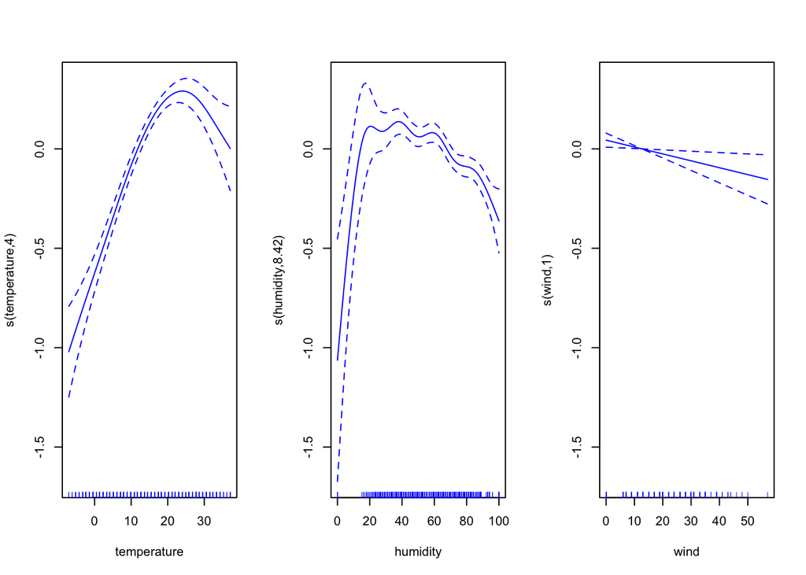

```r
par(mfrow=c(1,3))
plot(gam_5_test,se=TRUE,col="blue")
```

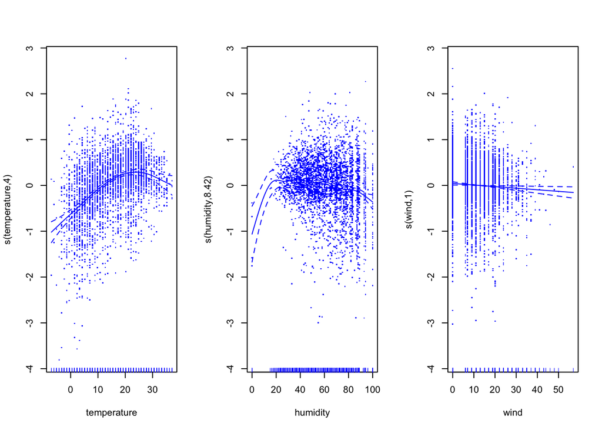

```r
par(mfrow=c(1,3))
plot(gam_5_test,residuals =TRUE,cex=2,col="blue")
```